# [누구나 따라 하는 금융 데이터 분석] - 주피터 노트북 기초 활용법

by JunPyo Park

Part of the Alpha Square Lecture Series:

- [[누구나 따라 하는 금융 데이터 분석] - 주피터 노트북 기초 활용법](http://blog.alphasquare.co.kr/221439837276)
- junpyopark.github.io

앞으로 진행될 금융 데이터 분석 콘텐츠에서는 주피터 노트북([공식 홈페이지](https://jupyter.org))을 활용합니다. 이번 콘텐츠에서는 주피터 노트북의 가장 기초적인 활용법들에 대해 정리해 보았습니다. 주피터 노트북 환경을 세팅하신 후 아래 내용을 천천히 따라 해 보신다면 쉽게 기본적인 명령어와 기능들에 익숙해질 수 있습니다. 주피터 노트북 환경이 갖추어지지 않으신 분은 아래의 링크를 통해 주피터 환경 구축이 가능합니다.

- [[알파스퀘어 - 아나콘다와 파이참을 이용하여 Jupyter notebook 실행하기]](http://blog.naver.com/anthouse28/221102899331)

# Table of Contents

## 코드 셀 vs 텍스트 셀

각각의 셀들은 코드를 담거나 텍스트를 담을 수 있습니다. 셀을 클릭 후 m 을 누르면 텍스트 셀(Markdown)로 활용할 수 있고 y 를 누르면 코드 셀로 활용할 수 있습니다.

## 명령어 실행하기

코드 셀은 실행 버튼을 누르거나 셀에서 쉬프트 엔터를 누르면 실행됩니다. 코드 셀에 명령어를 입력한 뒤 실행하면 각 줄의 내용이 실행되어 지고 결괏값이 셀의 마지막줄 아래에 출력됩니다.

```python
1 + 3
```

```
4
```

출력값이 없는 셀도 있을 수 있습니다. 다음과 같이 변수에 값을 할당하는 경우 입니다.

```python
X = 1
```

가장 마지막 줄에 있는 결괏값만 출력되어 집니다.

```python
2 + 2
3 + 3
```

```
6
```

마지막 줄이 아닌 곳의 값을 출력 하려면 `print` 명령어를 사용합니다.

```python
print(2 + 2)
3 + 3
```

```
4
```

```
6
```

## 셀이 동작하고 있을 경우

셀이 동작하고 있을 경우 `[*]` 기호가 왼쪽에 표시됩니다. 실행 되지 않은 셀의 경우 `[]` 기호가 표시됩니다. 실행된 셀은 `[5]` 와 같이 몇 번째 순서로 실행되었는지 그 숫자가 표기됩니다. 다음 셀을 실행 시키고 어떤 일이 벌어지는지 잘 관찰해 보세요.

```python
# 시간이 걸리는 코드를 작성해 보았습니다.
c = 0
for i in range(10000000):
    c = c + i
c
```

```
49999995000000
```

## 라이브러리 불러오기

대부분 작업의 경우 미리 만들어진 라이브러리에서 함수를 불러와 사용하게 됩니다. 아나콘다 환경에서는 기본적인 라이브러리들이 설치되어 있으며 설치되지 않은 라이브러리는 pip 명령어 등으로 설치하여 불러올 수 있습니다. 설치된 라이브러리는 `import` 명령어를 통해 불러올 수 있습니다.

```python
import numpy as np
import pandas as pd
import matplotlib.pyplot as plt
```

라이브러리를 불러온 후 `as` 라는 명령어를 통해 이름을 재설정 할 수 있습니다. numpy 라이브러리에는 `np` 라는 이름을 pandas 라이브러리에는 `pd` 라는 이름을 지정하였습니다. 이는 대부분의 코드에서 보편적으로 사용하는 이름입니다. 이처럼 라이브러리를 자주 호출하는 경우 단순한 이름으로 재설정하여 쉽게 접근할 수 있습니다.

## Tab 자동완성 기능

탭키를 누르면 주피터 노트북에서 다음에 쓸 명령어나 변수이름를 자동으로 추천하여 보여주거나 해당하는 값이 하나라면 자동으로 완성시켜 줍니다. 이는 코드를 작성할 때 많은 시간을 절약할 수 있도록 해줍니다. 이 기능을 활용하여 라이브러리에 어떤 함수들이 있는지 확인하는것도 가능합니다.

다음 셀에서 커서를 `.` 뒤에 두고 탭을 눌러보세요.

```python
np.random.
```

## Documentation 도움말 보기

물음표를 함수 뒤에 입력하고 해당 셀을 실행하면 주피터가 해당 함수에 대한 documentation을 보여줍니다. 코드가 재실행 되는것을 방지하기 위해 새로운 셀에서 이런 도움말 기능을 실행하면 편리합니다.

```python
np.random.normal?
```

## Sampling 하기

`numpy`의 여러 함수들을 통해 랜덤한 데이터를 샘플링 할 수 있습니다.

```python
# 평균이 0 이고 분산이 1 인 정규분포에서
# 100개의 데이터를 다음과 같이 추출할 수 있습니다.
X = np.random.normal(0, 1, 100)
```

## Plotting 하기

이전에 불러온 plt 라이브러리를 통해 그래프를 그릴 수 있습니다.

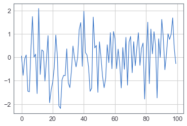

```python
plt.plot(X)
```

### Line Output 제거하기

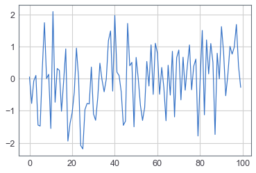

```python
plt.plot(X);
```

### 축에 이름 설정하기

`plt.xlabel` 또는 `plt.ylabel` 명령어를 통해 각각 x축, y축의 이름을 지정할 수 있습니다.

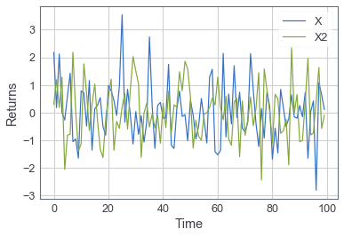

```python
X = np.random.normal(0, 1, 100)
X2 = np.random.normal(0, 1, 100)

plt.plot(X);
plt.plot(X2);
plt.xlabel('Time')
plt.ylabel('Returns')
plt.legend(['X', 'X2']);
```

## 통계량(statistics) 계산하기

`numpy`를 활용해서 간단한 통계량들을 쉽게 계산할 수 있습니다.

```python
# 평균
np.mean(X)
```

```
0.1230036394638333
```

```python
# 표준편차
np.std(X)
```

```
1.051931761394475
```

## 주가 데이터 불러오기

http://blog.naver.com/anthouse28/221408163989 참고해 주세요

```python
import pandas_datareader.data as web

data = web.DataReader('AAPL', 'robinhood')
```

```python
data
```

| symbol | begins_at | close_price | high_price | interpolated | low_price | open_price | session | volume |
| --- | --- | --- | --- | --- | --- | --- | --- | --- |
| AAPL | 2017-12-22 | 172.421400 | 172.829300 | False | 171.919000 | 172.096300 | reg | 16349444 |
|  | 2017-12-26 | 168.047100 | 168.933800 | False | 167.169300 | 168.273700 | reg | 33185536 |
|  | 2017-12-27 | 168.076600 | 168.254000 | False | 167.199800 | 167.584000 | reg | 21498213 |
|  | 2017-12-28 | 168.549500 | 169.308200 | False | 167.958400 | 168.470700 | reg | 16480187 |
|  | 2017-12-29 | 166.726900 | 168.066800 | False | 166.717100 | 167.997800 | reg | 25999922 |
|  | 2018-01-02 | 169.712100 | 169.751500 | False | 166.756500 | 167.643100 | reg | 25555934 |
|  | 2018-01-03 | 169.682500 | 171.968200 | False | 169.416500 | 169.978100 | reg | 29517899 |
|  | 2018-01-04 | 170.470700 | 170.904200 | False | 169.534700 | 169.987900 | reg | 22434597 |
|  | 2018-01-05 | 172.411600 | 172.776100 | False | 170.490400 | 170.874600 | reg | 23660018 |
|  | 2018-01-08 | 171.771200 | 173.012500 | False | 171.357400 | 171.771200 | reg | 20567766 |
|  | 2018-01-09 | 171.751500 | 172.470700 | False | 170.845100 | 171.968200 | reg | 21583997 |
|  | 2018-01-10 | 171.712100 | 171.721900 | False | 170.441100 | 170.598800 | reg | 23959895 |
|  | 2018-01-11 | 172.687400 | 172.892900 | False | 171.909100 | 172.007600 | reg | 18667729 |
|  | 2018-01-12 | 174.470600 | 174.736700 | False | 173.051900 | 173.574100 | reg | 25418080 |
|  | 2018-01-16 | 173.584000 | 176.736600 | False | 173.534700 | 175.268700 | reg | 29565947 |
|  | 2018-01-17 | 176.450900 | 176.598700 | False | 172.480500 | 173.544500 | reg | 34386836 |
|  | 2018-01-18 | 176.608500 | 177.436100 | False | 175.613500 | 176.716900 | reg | 31193352 |
|  | 2018-01-19 | 175.820400 | 176.923800 | False | 174.785900 | 175.968200 | reg | 32425067 |
|  | 2018-01-22 | 174.382000 | 175.150400 | False | 173.989500 | 174.677500 | reg | 27108551 |
|  | 2018-01-23 | 174.421400 | 176.785900 | False | 174.204600 | 174.677500 | reg | 32689146 |
|  | 2018-01-24 | 171.643100 | 174.677500 | False | 170.638200 | 174.628300 | reg | 51105090 |
|  | 2018-01-25 | 168.579100 | 172.362300 | False | 168.007700 | 171.923900 | reg | 41529004 |
|  | 2018-01-26 | 168.973200 | 169.455900 | False | 167.544600 | 169.455900 | reg | 39143011 |
|  | 2018-01-29 | 165.475700 | 167.643100 | False | 164.598900 | 167.643100 | reg | 50640406 |
|  | 2018-01-30 | 164.500300 | 164.894400 | False | 162.263900 | 163.076700 | reg | 46048185 |
|  | 2018-01-31 | 164.953500 | 165.950300 | False | 164.037300 | 164.401800 | reg | 32478930 |
|  | 2018-02-01 | 165.298400 | 166.125900 | False | 164.293400 | 164.692400 | reg | 47230787 |
|  | 2018-02-02 | 158.126000 | 164.332800 | False | 157.731900 | 163.544700 | reg | 86593825 |
|  | 2018-02-05 | 154.175300 | 161.456000 | False | 153.692600 | 156.746700 | reg | 72738522 |
|  | 2018-02-06 | 160.618600 | 161.298400 | False | 151.722200 | 152.539900 | reg | 68243838 |
|  | ... | ... | ... | ... | ... | ... | ... | ... |
|  | 2018-11-09 | 204.470000 | 206.010000 | False | 202.250000 | 205.550000 | reg | 34365750 |
|  | 2018-11-12 | 194.170000 | 199.850000 | False | 193.790000 | 199.000000 | reg | 51135518 |
|  | 2018-11-13 | 192.230000 | 197.180000 | False | 191.450100 | 191.630000 | reg | 46882936 |
|  | 2018-11-14 | 186.800000 | 194.480000 | False | 185.930000 | 193.900000 | reg | 60800957 |
|  | 2018-11-15 | 191.410000 | 191.970000 | False | 186.900000 | 188.390000 | reg | 46478801 |
|  | 2018-11-16 | 193.530000 | 194.969500 | False | 189.460000 | 190.500000 | reg | 36928253 |
|  | 2018-11-19 | 185.860000 | 190.700000 | False | 184.990000 | 190.000000 | reg | 41925292 |
|  | 2018-11-20 | 176.980000 | 181.470000 | False | 175.510000 | 178.370000 | reg | 67825247 |
|  | 2018-11-21 | 176.780000 | 180.270000 | False | 176.550000 | 179.730000 | reg | 31124210 |
|  | 2018-11-23 | 172.290000 | 176.595000 | False | 172.100000 | 174.940000 | reg | 23623972 |
|  | 2018-11-26 | 174.620000 | 174.950000 | False | 170.260000 | 174.240000 | reg | 44998520 |
|  | 2018-11-27 | 174.240000 | 174.770000 | False | 170.880000 | 171.510000 | reg | 41387377 |
|  | 2018-11-28 | 180.940000 | 181.290000 | False | 174.930000 | 176.730000 | reg | 46062539 |
|  | 2018-11-29 | 179.550000 | 182.800000 | False | 177.700000 | 182.660000 | reg | 41769992 |
|  | 2018-11-30 | 178.580000 | 180.330000 | False | 177.030000 | 180.290000 | reg | 39531549 |
|  | 2018-12-03 | 184.820000 | 184.940000 | False | 181.210000 | 184.460000 | reg | 40802482 |
|  | 2018-12-04 | 176.690000 | 182.389900 | False | 176.270000 | 180.950000 | reg | 41344282 |
|  | 2018-12-05 | 176.690000 | 176.690000 | True | 176.690000 | 176.690000 | reg | 0 |
|  | 2018-12-06 | 174.720000 | 174.780000 | False | 170.420000 | 171.760000 | reg | 43098410 |
|  | 2018-12-07 | 168.490000 | 174.490000 | False | 168.300000 | 173.490000 | reg | 42281631 |
|  | 2018-12-10 | 169.600000 | 170.090000 | False | 163.330000 | 165.000000 | reg | 62025994 |
|  | 2018-12-11 | 168.630000 | 171.790000 | False | 167.000000 | 171.660000 | reg | 47281665 |
|  | 2018-12-12 | 169.100000 | 171.920000 | False | 169.020000 | 170.400000 | reg | 35627674 |
|  | 2018-12-13 | 170.950000 | 172.570000 | False | 169.550000 | 170.490000 | reg | 31898647 |
|  | 2018-12-14 | 165.480000 | 169.080000 | False | 165.280000 | 169.000000 | reg | 40703710 |
|  | 2018-12-17 | 163.940000 | 168.350000 | False | 162.730000 | 165.450000 | reg | 44287922 |
|  | 2018-12-18 | 166.070000 | 167.530000 | False | 164.390000 | 165.380000 | reg | 33841518 |
|  | 2018-12-19 | 160.890000 | 167.450000 | False | 159.090000 | 166.000000 | reg | 49047297 |
|  | 2018-12-20 | 156.830000 | 162.110000 | False | 155.300000 | 160.400000 | reg | 64772960 |
| 2018-12-21 | 150.730000 | 158.160000 | False | 149.630000 | 156.860000 | reg | 95744584 |  |

252 rows × 7 columns

`data` 변수는 pandas.DataFrame 형태를 가지고 있습니다. [자세한 설명 보기](http://pandas.pydata.org/pandas-docs/stable/10min.html).

```python
X = data.loc['AAPL']['close_price'].astype('float')
```

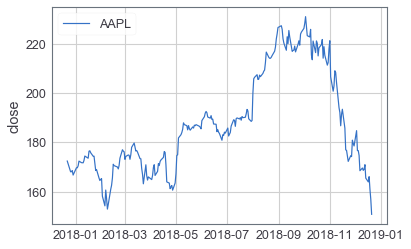

```python
plt.plot(X.index, X.values)
plt.ylabel('close')
plt.legend(['AAPL']);
```

실제 데이터에서 통계량을 계산할 수 있습니다.

```python
np.mean(X)
```

```
188.02081944444456
```

```python
np.std(X)
```

```
20.454761929633772
```

## 가격으로 부터 수익률 계산하기

`pct_change`(percent change) 라는 함수를 사용하여 일간 수익률을 쉽게 계산할 수 있습니다.

```python
R = X.pct_change()
```

```python
R.head()
```

```
begins_at
2017-12-22         NaN
2017-12-26   -0.025370
2017-12-27    0.000176
2017-12-28    0.002814
2017-12-29   -0.010813
Name: close_price, dtype: float64
```

R 값을 확인해 보면 처음 데이터의 경우 기준이 되는 이전일의 데이터가 없기 때문에 NaN(Not a Number)라는 값이 저장되어 있습니다. 다음과 같은 조작을 통해 이 값을 없앨 수 있습니다.

```python
R = X.pct_change()[1:]
```

```python
R.head()
```

```
begins_at
2017-12-26   -0.025370
2017-12-27    0.000176
2017-12-28    0.002814
2017-12-29   -0.010813
2018-01-02    0.017905
Name: close_price, dtype: float64
```

`plt.hist` 함수를 사용하여 일간 수익률 히스토그램을 그려보도록 하겠습니다.

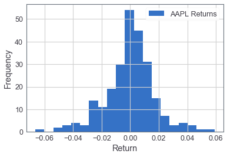

```python
# 구간의 범위를 몇 등분 할것인지 bins 개수를 통해 조절 가능합니다.
plt.hist(R, bins=20)
plt.xlabel('Return')
plt.ylabel('Frequency')
plt.legend(['AAPL Returns']);
```

통계량을 계산해 봅시다.

```python
np.mean(R)
```

```
-0.0003816818079786287
```

```python
np.std(R)
```

```
0.017506270274000497
```

위의 수익률 데이터로 부터 측정된 평균과 표준편차 값을 바탕으로 정규분포를 그려 보도록 하겠습니다. 그려진 정규분포와 실제 데이터의 수익률 분포 비교를 통해 실제 수익률이 정규분포를 따르는지 추정해 볼 수 있습니다.

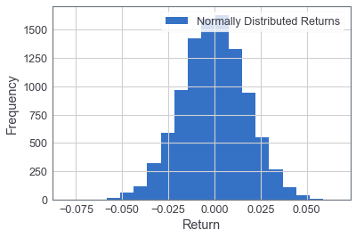

```python
plt.hist(np.random.normal(np.mean(R), np.std(R), 10000), bins=20)
plt.xlabel('Return')
plt.ylabel('Frequency')
plt.legend(['Normally Distributed Returns']);
```

유사한 형태를 보이지만 완전히 같다고는 보기 힘들다 생각됩니다. 일단 오늘은 이렇게 간단히 히스토그램을 그려 모양을 통해 추정해 보는것으로 글을 마치도록 하겠습니다. 실제데이터가 조금더 엄밀하게 정규분포를 따르는지 확인하려면 자크베라의 정규성 검정(Jacque-Bera Normality test)과 같은 방식을 활용해야 합니다. 이는 추후 가설 검정 부분 이후 소개하도록 하겠습니다.